# Analyzing The College Dataset

First let's import the necessary libraries.

```python
import numpy as np
import pandas as pd
import os
import random
import scipy.stats as st

random.seed(42)
```

Also import the visualization libraries.

```python
%matplotlib inline

import matplotlib as mlt
import matplotlib.pyplot as plt
import seaborn as sns

plt.style.use('ggplot')
```

**Let's define a function so that we can easily load the datasets.**

```python
DATASET_PATH = 'Workable Datasets'

def load_the_dataset(file_name, dataset_path=DATASET_PATH):
    csv_path = os.path.join(dataset_path, file_name)
    return pd.read_csv(csv_path)
```

**Let's import the dataset.**

```python
college_df = load_the_dataset('COLLEGE_N.csv')
```

**Let's check the data.**

```python
college_df.head()
```

|  | Gender | Age | Popular Website | Proficiency | Medium | Location | Household Internet Facilities | Browse Time | Browsing Status | Residence | Total Internet Usage(hrs/day) | Time Spent in Academic(hrs/day) | Purpose of Use | Years of Internet Use | Browsing Purpose | Priority of Learning | Webinar | Internet Usage For Educational Purpose | Academic Performance | Obstacles |
| --- | --- | --- | --- | --- | --- | --- | --- | --- | --- | --- | --- | --- | --- | --- | --- | --- | --- | --- | --- | --- |
| 0 | Female | 17 | Google | Very Good | Mobile | Home | Not Connected | Night | Daily | Town | 2 | 4 | Blog | 3 | Non-academic | Creativity and Innovative Skills | No | Articles or Blogs related to non-academical st... | Not Satisfactory | Bad Service |
| 1 | Female | 17 | Facebook | Good | Mobile | Home | Not Connected | Night | Daily | Town | 8 | 0 | Social Media | 3 | Non-academic | Creativity and Innovative Skills | No | Notes or lectures for academical purpose | Average | High Price |
| 2 | Female | 17 | Youtube | Very Good | Mobile | Home | Not Connected | Night | Daily | Town | 6 | 2 | Entertainment | 3 | Non-academic | Career Opportunity | No | Articles or Blogs related to non-academical st... | Average | High Price |
| 3 | Female | 18 | Youtube | Good | Mobile | Home | Not Connected | Night | Weekly | Town | 7 | 0 | Entertainment | 2 | Non-academic | Non-academic Learning | Yes | E-books or other Media files | Average | Unavailability |
| 4 | Male | 17 | Whatsapp | Very Good | Mobile | Home | Not Connected | Night | Daily | Town | 4 | 4 | News | 4 | Academic | Communication Skills | No | E-books or other Media files | Average | Bad Service |

### Check the dataset using `info()`.

```python
college_df.info()
```

```
<class 'pandas.core.frame.DataFrame'>
RangeIndex: 199 entries, 0 to 198
Data columns (total 20 columns):
 #   Column                                  Non-Null Count  Dtype
---  ------                                  --------------  -----
 0   Gender                                  199 non-null    object
 1   Age                                     199 non-null    int64
 2   Popular Website                         199 non-null    object
 3   Proficiency                             199 non-null    object
 4   Medium                                  199 non-null    object
 5   Location                                199 non-null    object
 6   Household Internet Facilities           199 non-null    object
 7   Browse Time                             199 non-null    object
 8   Browsing Status                         199 non-null    object
 9   Residence                               199 non-null    object
 10  Total Internet Usage(hrs/day)           199 non-null    int64
 11  Time Spent in Academic(hrs/day)         199 non-null    int64
 12  Purpose of Use                          199 non-null    object
 13  Years of Internet Use                   199 non-null    int64
 14  Browsing Purpose                        199 non-null    object
 15  Priority of Learning                    199 non-null    object
 16  Webinar                                 199 non-null    object
 17  Internet Usage For Educational Purpose  199 non-null    object
 18  Academic Performance                    199 non-null    object
 19  Obstacles                               199 non-null    object
dtypes: int64(4), object(16)
memory usage: 31.2+ KB
```

### Let's check the `shape`.

```python
college_df.shape
```

```
(199, 20)
```

### Now let's check all the categorical attributes individually. Start with `Gender` first.

```python
college_df['Gender'].value_counts()
```

```
Female    131
Male       68
Name: Gender, dtype: int64
```

### Check `Age`

```python
college_df['Age'].value_counts()
```

```
17    171
18     12
16      8
15      8
Name: Age, dtype: int64
```

### Check `Frequently Visited Website`

```python
college_df['Popular Website'].value_counts()
```

```
Google      54
Facebook    44
Whatsapp    43
Youtube     31
Gmail       18
Twitter      9
Name: Popular Website, dtype: int64
```

```python
college_df.rename(columns={
    'Popular Website':'Frequently Visited Website',
}, inplace=True)

college_df.columns
```

```
Index(['Gender', 'Age', 'Frequently Visited Website', 'Proficiency', 'Medium',
       'Location', 'Household Internet Facilities', 'Browse Time',
       'Browsing Status', 'Residence', 'Total Internet Usage(hrs/day)',
       'Time Spent in Academic(hrs/day)', 'Purpose of Use',
       'Years of Internet Use', 'Browsing Purpose', 'Priority of Learning',
       'Webinar', 'Internet Usage For Educational Purpose',
       'Academic Performance', 'Obstacles'],
      dtype='object')
```

### Check `Effectiveness Of Internet Usage`

```python
college_df['Proficiency'].value_counts()
```

```
Very Good    71
Good         69
Average      59
Name: Proficiency, dtype: int64
```

```python
college_df.rename(columns={
    'Proficiency':'Effectiveness Of Internet Usage'
}, inplace=True)

college_df.columns
```

```
Index(['Gender', 'Age', 'Frequently Visited Website',
       'Effectiveness Of Internet Usage', 'Medium', 'Location',
       'Household Internet Facilities', 'Browse Time', 'Browsing Status',
       'Residence', 'Total Internet Usage(hrs/day)',
       'Time Spent in Academic(hrs/day)', 'Purpose of Use',
       'Years of Internet Use', 'Browsing Purpose', 'Priority of Learning',
       'Webinar', 'Internet Usage For Educational Purpose',
       'Academic Performance', 'Obstacles'],
      dtype='object')
```

```python
college_df.replace({'Effectiveness Of Internet Usage': {'Very Good':'Very Effective', 'Good':'Effective',
                                                        'Average':'Somewhat Effective'}}, inplace=True)
```

```python
college_df['Effectiveness Of Internet Usage'].value_counts()
```

```
Very Effective        71
Effective             69
Somewhat Effective    59
Name: Effectiveness Of Internet Usage, dtype: int64
```

### Check `Devices Used For Internet Browsing`

```python
college_df['Medium'].value_counts()
```

```
Mobile               159
Laptop and Mobile     27
Desktop               13
Name: Medium, dtype: int64
```

```python
college_df.rename(columns={
    'Medium':'Devices Used For Internet Browsing',
}, inplace=True)

college_df.columns
```

```
Index(['Gender', 'Age', 'Frequently Visited Website',
       'Effectiveness Of Internet Usage', 'Devices Used For Internet Browsing',
       'Location', 'Household Internet Facilities', 'Browse Time',
       'Browsing Status', 'Residence', 'Total Internet Usage(hrs/day)',
       'Time Spent in Academic(hrs/day)', 'Purpose of Use',
       'Years of Internet Use', 'Browsing Purpose', 'Priority of Learning',
       'Webinar', 'Internet Usage For Educational Purpose',
       'Academic Performance', 'Obstacles'],
      dtype='object')
```

### Check `Location Of Internet Use`

```python
college_df['Location'].value_counts()
```

```
Home          186
College        12
Cyber Cafe      1
Name: Location, dtype: int64
```

```python
college_df.rename(columns={
    'Location':'Location Of Internet Use'
}, inplace=True)

college_df.columns
```

```
Index(['Gender', 'Age', 'Frequently Visited Website',
       'Effectiveness Of Internet Usage', 'Devices Used For Internet Browsing',
       'Location Of Internet Use', 'Household Internet Facilities',
       'Browse Time', 'Browsing Status', 'Residence',
       'Total Internet Usage(hrs/day)', 'Time Spent in Academic(hrs/day)',
       'Purpose of Use', 'Years of Internet Use', 'Browsing Purpose',
       'Priority of Learning', 'Webinar',
       'Internet Usage For Educational Purpose', 'Academic Performance',
       'Obstacles'],
      dtype='object')
```

### Check `Household Internet Facilities`

```python
college_df['Household Internet Facilities'].value_counts()
```

```
Not Connected    176
Connected         23
Name: Household Internet Facilities, dtype: int64
```

### Check `Time Of Internet Browsing`

```python
college_df['Browse Time'].value_counts()
```

```
Night       168
Day          30
Midnight      1
Name: Browse Time, dtype: int64
```

```python
college_df.rename(columns={
       'Browse Time':'Time Of Internet Browsing',
}, inplace=True)

college_df.columns
```

```
Index(['Gender', 'Age', 'Frequently Visited Website',
       'Effectiveness Of Internet Usage', 'Devices Used For Internet Browsing',
       'Location Of Internet Use', 'Household Internet Facilities',
       'Time Of Internet Browsing', 'Browsing Status', 'Residence',
       'Total Internet Usage(hrs/day)', 'Time Spent in Academic(hrs/day)',
       'Purpose of Use', 'Years of Internet Use', 'Browsing Purpose',
       'Priority of Learning', 'Webinar',
       'Internet Usage For Educational Purpose', 'Academic Performance',
       'Obstacles'],
      dtype='object')
```

### Check `Frequency Of Internet Usage`

```python
college_df['Browsing Status'].value_counts()
```

```
Daily      156
Weekly      40
Monthly      3
Name: Browsing Status, dtype: int64
```

```python
college_df.rename(columns={
    'Browsing Status':'Frequency Of Internet Usage',
}, inplace=True)

college_df.columns
```

```
Index(['Gender', 'Age', 'Frequently Visited Website',
       'Effectiveness Of Internet Usage', 'Devices Used For Internet Browsing',
       'Location Of Internet Use', 'Household Internet Facilities',
       'Time Of Internet Browsing', 'Frequency Of Internet Usage', 'Residence',
       'Total Internet Usage(hrs/day)', 'Time Spent in Academic(hrs/day)',
       'Purpose of Use', 'Years of Internet Use', 'Browsing Purpose',
       'Priority of Learning', 'Webinar',
       'Internet Usage For Educational Purpose', 'Academic Performance',
       'Obstacles'],
      dtype='object')
```

### Check `Place Of Student's Residence`

```python
college_df['Residence'].value_counts()
```

```
Town       167
Village     25
Remote       7
Name: Residence, dtype: int64
```

```python
college_df.rename(columns={
    'Residence':'Place Of Student\'s Residence',
}, inplace=True)

college_df.columns
```

```
Index(['Gender', 'Age', 'Frequently Visited Website',
       'Effectiveness Of Internet Usage', 'Devices Used For Internet Browsing',
       'Location Of Internet Use', 'Household Internet Facilities',
       'Time Of Internet Browsing', 'Frequency Of Internet Usage',
       'Place Of Student's Residence', 'Total Internet Usage(hrs/day)',
       'Time Spent in Academic(hrs/day)', 'Purpose of Use',
       'Years of Internet Use', 'Browsing Purpose', 'Priority of Learning',
       'Webinar', 'Internet Usage For Educational Purpose',
       'Academic Performance', 'Obstacles'],
      dtype='object')
```

### Check `Purpose Of Internet Use`

```python
college_df['Purpose of Use'].value_counts()
```

```
Social Media       67
Entertainment      45
Education          27
Blog               22
News               20
Online Shopping    18
Name: Purpose of Use, dtype: int64
```

```python
college_df.rename(columns={
    'Purpose of Use':'Purpose Of Internet Use',
}, inplace=True)

college_df.columns
```

```
Index(['Gender', 'Age', 'Frequently Visited Website',
       'Effectiveness Of Internet Usage', 'Devices Used For Internet Browsing',
       'Location Of Internet Use', 'Household Internet Facilities',
       'Time Of Internet Browsing', 'Frequency Of Internet Usage',
       'Place Of Student's Residence', 'Total Internet Usage(hrs/day)',
       'Time Spent in Academic(hrs/day)', 'Purpose Of Internet Use',
       'Years of Internet Use', 'Browsing Purpose', 'Priority of Learning',
       'Webinar', 'Internet Usage For Educational Purpose',
       'Academic Performance', 'Obstacles'],
      dtype='object')
```

### Check `Browsing Purpose`

```python
college_df['Browsing Purpose'].value_counts()
```

```
Non-academic    115
Academic         84
Name: Browsing Purpose, dtype: int64
```

### Check `Webinar`

```python
college_df['Webinar'].value_counts()
```

```
No     171
Yes     28
Name: Webinar, dtype: int64
```

### Check `Priority Of Learning On The Internet`

```python
college_df['Priority of Learning'].value_counts()
```

```
Non-academic Learning               58
Communication Skills                44
Academic Learning                   39
Creativity and Innovative Skills    24
Leadership Development              19
Career Opportunity                  15
Name: Priority of Learning, dtype: int64
```

```python
college_df.rename(columns={
    'Priority of Learning':'Priority Of Learning On The Internet',
}, inplace=True)

college_df.columns
```

```
Index(['Gender', 'Age', 'Frequently Visited Website',
       'Effectiveness Of Internet Usage', 'Devices Used For Internet Browsing',
       'Location Of Internet Use', 'Household Internet Facilities',
       'Time Of Internet Browsing', 'Frequency Of Internet Usage',
       'Place Of Student's Residence', 'Total Internet Usage(hrs/day)',
       'Time Spent in Academic(hrs/day)', 'Purpose Of Internet Use',
       'Years of Internet Use', 'Browsing Purpose',
       'Priority Of Learning On The Internet', 'Webinar',
       'Internet Usage For Educational Purpose', 'Academic Performance',
       'Obstacles'],
      dtype='object')
```

### Check `Internet Usage For Educational Purpose`

```python
college_df['Internet Usage For Educational Purpose'].value_counts()
```

```
Articles or Blogs related to non-academical studies    59
Notes or lectures for academical purpose               45
Articles or Blogs related to academical studies        37
E-books or other Media files                           33
Courses Available on specific topics                   25
Name: Internet Usage For Educational Purpose, dtype: int64
```

### Check `Academic Performance`

```python
college_df['Academic Performance'].value_counts()
```

```
Average             91
Satisfactory        44
Not Satisfactory    38
Good                26
Name: Academic Performance, dtype: int64
```

```python
college_df.replace({'Academic Performance': {'Good':'Excellent', 'Satisfactory':'Good'}}, inplace=True)
```

```python
college_df['Academic Performance'].value_counts()
```

```
Average             91
Good                44
Not Satisfactory    38
Excellent           26
Name: Academic Performance, dtype: int64
```

### Check `Barriers To Internet Access`

```python
college_df['Obstacles'].value_counts()
```

```
Bad Service       88
High Price        83
Unavailability    28
Name: Obstacles, dtype: int64
```

```python
college_df.rename(columns={
    'Obstacles':'Barriers To Internet Access',
}, inplace=True)

college_df.columns
```

```
Index(['Gender', 'Age', 'Frequently Visited Website',
       'Effectiveness Of Internet Usage', 'Devices Used For Internet Browsing',
       'Location Of Internet Use', 'Household Internet Facilities',
       'Time Of Internet Browsing', 'Frequency Of Internet Usage',
       'Place Of Student's Residence', 'Total Internet Usage(hrs/day)',
       'Time Spent in Academic(hrs/day)', 'Purpose Of Internet Use',
       'Years of Internet Use', 'Browsing Purpose',
       'Priority Of Learning On The Internet', 'Webinar',
       'Internet Usage For Educational Purpose', 'Academic Performance',
       'Barriers To Internet Access'],
      dtype='object')
```

## Plot the data

Now we can plot the data. Let's write a couple of functions so that we easily plot the data.

**This function saves the figures.**

```python
# Write a function to save the figures
PROJECT_ROOT_DIR = "."
DATASET_ID = "College"
IMAGES_PATH = os.path.join(PROJECT_ROOT_DIR, "Figures", DATASET_ID)
os.makedirs(IMAGES_PATH, exist_ok = True)

def save_fig(fig_id, tight_layout=True, fig_extension="png", resolution=300):
    path = os.path.join(IMAGES_PATH, fig_id + "." + fig_extension)
    print("Saving figure", fig_id)
    if tight_layout:
        plt.tight_layout()
    plt.savefig(path, format=fig_extension, dpi=resolution)
```

```python
def numerical_data_plot(dataframe, fig_id, hist_alpha=0.6, color='crimson',
                        title='Image Title', xlabel='X Label', ylabel='Y Label'):

#     plt.figure(figsize=(10, 6))
#     sns.set(font_scale=1.5)

#     plt.subplot(121)

    count, bin_edges = np.histogram(dataframe)
    dataframe.plot(kind='hist', alpha=hist_alpha,
                   xticks=bin_edges, color=color)

    # Let's add a KDE plot
#     mn, mx = plt.xlim()
#     plt.xlim(mn, mx)
#     kde_x = np.linspace(mn, mx, 300)
#     kde = st.gaussian_kde(dataframe)
#     plt.plot(kde_x, kde.pdf(kde_x) * kde_mul, 'k--', color=color)
#     kde_mul=1000,

#     plt.title(title)
    plt.xlabel(xlabel)
    plt.ylabel(ylabel)

#     plt.subplot(122)
#     red_circle = dict(markerfacecolor='r', marker='o')
#     dataframe.plot(kind='box', color=color, flierprops=red_circle)

#     save_fig(fig_id)
```

**This function plots histograms of the given categorical data.**

```python
def categorical_bar_plot(dataframe, rot=0, alpha=0.80, color = ['steelblue', 'crimson'],
                         title='Distribution', xlabel = 'Column name', ylabel='Number of students'):

    dataframe.value_counts().plot(kind='bar', rot=rot, alpha=alpha, color=color)

    plt.title(title, fontweight='bold')
    plt.xlabel(xlabel, fontweight='bold')
    plt.ylabel(ylabel, fontweight='bold')
```

**let's define a function to create scatter plots of the numerical values and check the distribution of the attribute values against the target column, `Academic Performance`**

```python
def categorical_scatter_plot(dataframe, x_column, y_column, title, legend_title,
                             y_label, x_label = 'Number of students'):

    plt.figure(figsize=(15, 7))
    sns.set(font_scale=1.5)
    sns.set_style("whitegrid", {'axes.grid' : False})

    plt.plot(dataframe[x_column].loc[dataframe[y_column] == 'Excellent'].index,
             dataframe[x_column].loc[dataframe[y_column] == 'Excellent'],
             'bo', label = 'Excellent')

    plt.plot(dataframe[x_column].loc[dataframe[y_column] == 'Good'].index,
             dataframe[x_column].loc[dataframe[y_column] == 'Good'],
             'yo', label = 'Good')

    plt.plot(dataframe[x_column].loc[dataframe[y_column] == 'Average'].index,
             dataframe[x_column].loc[dataframe[y_column] == 'Average'],
             'go', label = 'Average')

    plt.plot(dataframe[x_column].loc[dataframe[y_column] == 'Not Satisfactory'].index,
             dataframe[x_column].loc[dataframe[y_column] == 'Not Satisfactory'],
             'ro', label = 'Not Satisfactory')

#     plt.title(title, fontweight='bold')
    plt.xlabel(x_label, fontweight='bold')
    plt.ylabel(y_label, fontweight='bold')
    plt.legend(title = legend_title, title_fontsize=14, loc='lower right', fontsize=14)
```

**A modification of the previous function to create scatter plots of the numerical values vs numerical values and check the distribution of the attribute values against the target column, `Academic Performance`**

```python
def categorical_scatter_plot_wrt_academic_performance(dataframe, x_column, y_column, title,
                             y_label, x_label, legend_title):

    plt.figure(figsize=(15, 7))
    sns.set(font_scale=1.2)
    sns.set_style("whitegrid", {'axes.grid' : False})

    plt.plot(dataframe[x_column].loc[dataframe['Academic Performance'] == 'Excellent'],
             dataframe[y_column].loc[dataframe['Academic Performance'] == 'Excellent'],
             'bo', label = 'Excellent')

    plt.plot(dataframe[x_column].loc[dataframe['Academic Performance'] == 'Good'],
             dataframe[y_column].loc[dataframe['Academic Performance'] == 'Good'],
             'yo', label = 'Good')

    plt.plot(dataframe[x_column].loc[dataframe['Academic Performance'] == 'Average'],
             dataframe[y_column].loc[dataframe['Academic Performance'] == 'Average'],
             'go', label = 'Average')

    plt.plot(dataframe[x_column].loc[dataframe['Academic Performance'] == 'Not Satisfactory'],
             dataframe[y_column].loc[dataframe['Academic Performance'] == 'Not Satisfactory'],
             'ro', label = 'Not Satisfactory')

#     plt.title(title, fontweight='bold')
    plt.xlabel(x_label, fontweight='bold')
    plt.ylabel(y_label, fontweight='bold')
    plt.legend(title = legend_title, loc='upper right', fontsize=14)
```

**This function plot histograms of the categorical values against the `'Academic Performance'` column.**

These are helper functions.

```python
def init_dictionary(dictionary, labels):
    for label in labels:
        dictionary[label] = []

def append_to_dict(dictionary, indexes, values):
    x = 0
    for index in indexes:
        dictionary[index].append(values[x])
        x += 1

def furnish_the_lists(labels, indexes, values):
    list_dif = [i for i in labels + indexes if i not in labels or i not in indexes]

    indexes.extend(list_dif)
    for i in range(len(list_dif)):
        values.append(0)

def append_dataframe_to_dict(dataframe, column_name, labels, dictionary):
    values = dataframe[column_name].value_counts().tolist()
    indexes = dataframe[column_name].value_counts().index.tolist()
    furnish_the_lists(labels, indexes, values)
    append_to_dict(dictionary, indexes, values)

    return dictionary
```

This is the main function.

```python
def cat_vs_cat_bar_plot(dataframe, column_name, column_cat_list):
    excellent_result_df = dataframe.loc[dataframe['Academic Performance'] == 'Excellent']
    good_result_df = dataframe.loc[dataframe['Academic Performance'] == 'Good']
    average_result_df = dataframe.loc[dataframe['Academic Performance'] == 'Average']
    unsatisfactory_result_df = dataframe.loc[dataframe['Academic Performance'] == 'Not Satisfactory']

    labels = column_cat_list
    dictionary = {}

    init_dictionary(dictionary, labels)

    dictionary = append_dataframe_to_dict(excellent_result_df, column_name, labels, dictionary)
    dictionary = append_dataframe_to_dict(good_result_df, column_name, labels, dictionary)
    dictionary = append_dataframe_to_dict(average_result_df, column_name, labels, dictionary)
    dictionary = append_dataframe_to_dict(unsatisfactory_result_df, column_name, labels, dictionary)

    return dictionary
```

**The following function does the same thing with respect to `'Browsing Purpose'`**

```python
def cat_vs_cat_bar_plot_browsing_purpose(dataframe, column_name, column_cat_list):
    academic_df = dataframe.loc[dataframe['Browsing Purpose'] == 'Academic']
    non_academic_df = dataframe.loc[dataframe['Browsing Purpose'] == 'Non-academic']

    labels = column_cat_list
    dictionary = {}

    init_dictionary(dictionary, labels)

    dictionary = append_dataframe_to_dict(academic_df, column_name, labels, dictionary)
    dictionary = append_dataframe_to_dict(non_academic_df, column_name, labels, dictionary)

    return dictionary
```

**This function add value counts on top of each bar in the histogram.**

```python
def autolabel(rects):

    total_height = 0

    for rect in rects:
        total_height += rect.get_height()

    for rect in rects:
        height = rect.get_height()
        ax.annotate('{}'.format("{:.2f}".format((height/total_height)*100)) + '%',
                    xy = (rect.get_x() + rect.get_width()/2, height),
                    xytext = (0, 3), # 3 points vertical offset
                    textcoords = "offset points",
                    ha = 'center', va = 'bottom')
```

**Now let's start plotting the data.**

### Plotting Non-Categorical Values

Only `'Total Internet Usage(hrs/day)'`, `'Time Spent in Academic(hrs/day)'`, `'Duration Of Internet Usage(In Years)'` are the non-categorical values in the dataset.

**Let's plot the bar plot for each of the non-categorical attributes together.**

```
Saving figure Non_Categorical_Bar_plot_collage_1
```

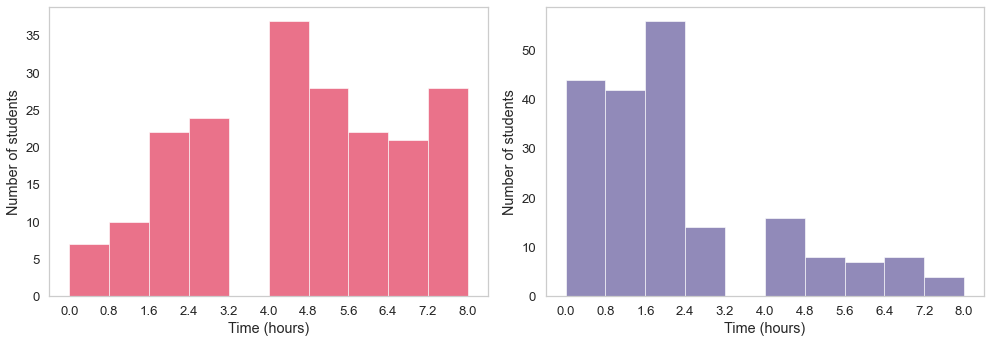

```python
plt.figure(figsize=(14, 5))
plt.subplots_adjust(top=0.5, bottom=0.1, hspace=0.5, wspace=0.2)
sns.set(font_scale=1.2)
sns.set_style("whitegrid", {'axes.grid' : False})

plt.subplot(121)
numerical_data_plot(college_df['Total Internet Usage(hrs/day)'], 'Total_Internet_Usage_Histogram',
                    title = 'Total internet usage in a day',
                    xlabel = 'Time (hours)', ylabel = 'Number of students')

plt.subplot(122)
numerical_data_plot(college_df['Time Spent in Academic(hrs/day)'], 'Time_Spent_in_Academics_Histogram',
                    hist_alpha=0.6, color='darkslateblue',
                    title='Total time spent in academic studies in a day',
                    xlabel='Time (hours)', ylabel='Number of students')


save_fig('Non_Categorical_Bar_plot_collage_1')

plt.show()
```

```python
# plt.figure(figsize=(7, 5))
# plt.subplots_adjust(top=0.5, bottom=0.1, hspace=0.5, wspace=0.2)
# sns.set(font_scale=1.2)

# numerical_data_plot(college_df['Duration Of Internet Usage(In Years)'], 'Duration_Of_Internet_Usage_Histogram',
#                     hist_alpha=0.6, color='salmon', title='How Long Have The Students Been Using Internet?',
#                     xlabel='Time(years)', ylabel='Number of Students')


# save_fig('Non_Categorical_Bar_plot_2')

# plt.show()
```

### Plotting `Total Internet Usage(hrs/day)`

```python
college_df['Total Internet Usage(hrs/day)'].value_counts()
```

```
4    37
8    28
5    28
3    24
6    22
2    22
7    21
1    10
0     7
Name: Total Internet Usage(hrs/day), dtype: int64
```

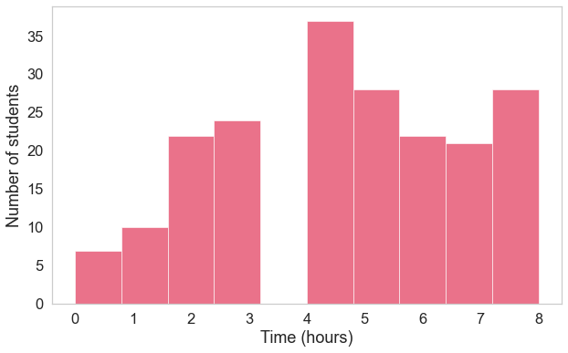

```python
plt.figure(figsize=(10, 6))
sns.set(font_scale=1.5)
sns.set_style("whitegrid", {'axes.grid' : False})

college_df['Total Internet Usage(hrs/day)'].plot(kind='hist', alpha=0.6, color='crimson')

plt.xlabel('Time (hours)')
plt.ylabel('Number of students')

plt.show()
```

Now let's check the scatter plot.

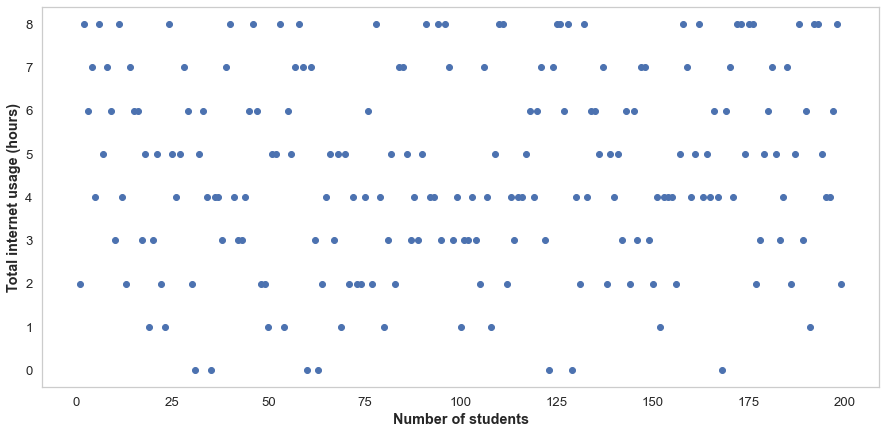

```python
plt.figure(figsize=(15,7))
sns.set(font_scale=1.2)
sns.set_style("whitegrid", {'axes.grid' : False})

plt.plot(np.linspace(1, len(college_df.index), len(college_df.index)),
         college_df['Total Internet Usage(hrs/day)'], 'bo')

plt.ylabel('Total internet usage (hours)', fontweight='bold')
plt.xlabel('Number of students', fontweight='bold')


plt.show()
```

Now let's try plotting `Total Internet Usage(hrs/day)` against the target column `'Academic Performance'`.

```
Saving figure Total_Internet_Usage_In_A_Day_WRT_Academic_Performance_Scatter_Plot
```

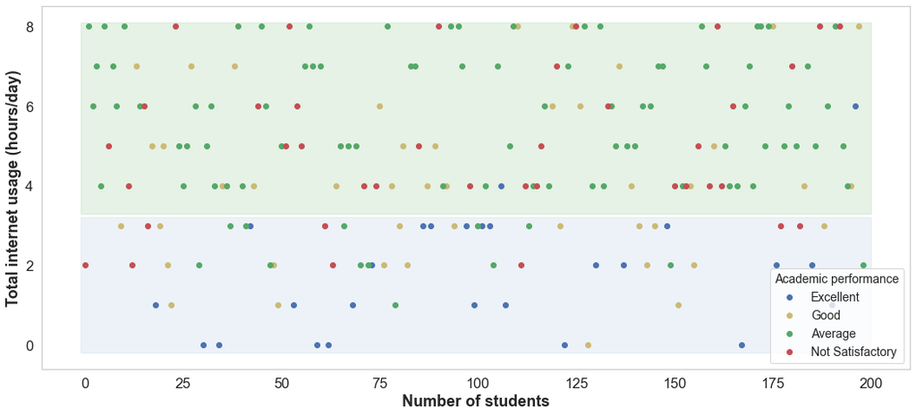

```python
categorical_scatter_plot(college_df, 'Total Internet Usage(hrs/day)', 'Academic Performance',
                        'Total Internet Usage In A Day W.R.T. Academic Performance', 'Academic performance',
                         'Total internet usage (hours/day)')

plt.fill_between([-1, 200], [3.2, 3.2], -0.2, color='steelblue', alpha=0.1, interpolate=True)
plt.fill_between([-1, 200], [8.1, 8.1], 3.3, color='green', alpha=0.1, interpolate=True)

save_fig('Total_Internet_Usage_In_A_Day_WRT_Academic_Performance_Scatter_Plot')

plt.show()
```

### Plotting `Time Spent in Academic(hrs/day)`

```python
college_df['Time Spent in Academic(hrs/day)'].value_counts()
```

```
2    56
0    44
1    42
4    16
3    14
7     8
5     8
6     7
8     4
Name: Time Spent in Academic(hrs/day), dtype: int64
```

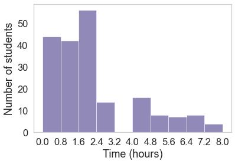

```python
numerical_data_plot(college_df['Time Spent in Academic(hrs/day)'], 'Time_Spent_in_Academic_Histogram_BoxPlot',
                    hist_alpha=0.6, color='darkslateblue',
                    title='Total time spent in academic studies in a day',
                    xlabel='Time (hours)', ylabel='Number of students')

plt.show()
```

Now let's check the scatter plot.

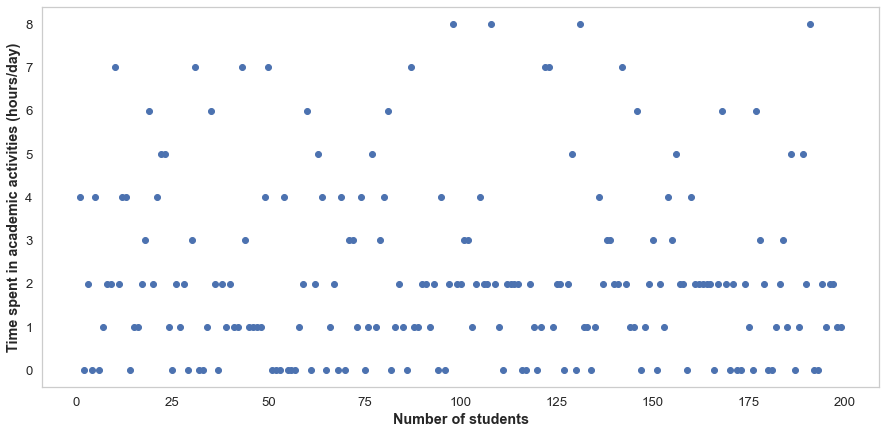

```python
plt.figure(figsize=(15,7))
sns.set(font_scale=1.2)
sns.set_style("whitegrid", {'axes.grid' : False})

plt.plot(np.linspace(1, len(college_df.index), len(college_df.index)),
         college_df['Time Spent in Academic(hrs/day)'], 'bo')

# plt.title('Total time spent in academic in a day', fontweight='bold')
plt.ylabel('Time spent in academic activities (hours/day)', fontweight='bold')
plt.xlabel('Number of students', fontweight='bold')

plt.show()
```

Now let's try plotting `Time Spent in Academic(hrs/day)` against the target column `'Academic Performance'`.

```
Saving figure Time_Spent_In_Academic_In_A_Day_WRT_Academic_Performance_Scatter_Plot
```

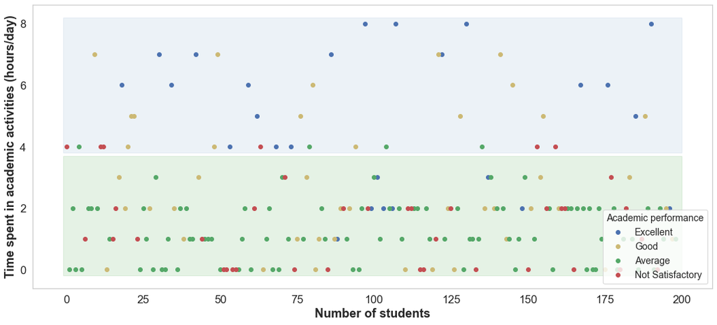

```python
categorical_scatter_plot(college_df, 'Time Spent in Academic(hrs/day)', 'Academic Performance',
                         'Time Spent In Academic In A Day W.R.T. Academic Performance', 'Academic performance',
                         'Time spent in academic activities (hours/day)')

plt.fill_between([-1, 200], [8.2, 8.2], 3.8, color='steelblue', alpha=0.1, interpolate=True)
plt.fill_between([-1, 200], [3.7, 3.7], -0.2, color='green', alpha=0.1)

save_fig('Time_Spent_In_Academic_In_A_Day_WRT_Academic_Performance_Scatter_Plot')

plt.show()
```

### Plotting `Time Spent in Academic(hrs/day)` vs `Total Internet Usage(hrs/day)`

Let's use scatter plot.

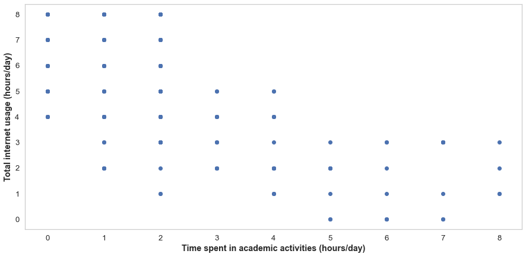

```python
plt.figure(figsize=(15, 7))
sns.set(font_scale=1.2)
sns.set_style("whitegrid", {'axes.grid' : False})

plt.plot(college_df['Time Spent in Academic(hrs/day)'],
         college_df['Total Internet Usage(hrs/day)'], 'bo')

# plt.title('Time Spent in Academic(hrs/day) vs Total Internet Usage(hrs/day)', fontweight='bold')
plt.xlabel('Time spent in academic activities (hours/day)', fontweight='bold')
plt.ylabel('Total internet usage (hours/day)', fontweight='bold')

plt.show()
```

**Now let's try plotting `Time Spent in Academic(hrs/day)` vs `'Total Internet Usage(hrs/day)'` against the target `'Academic Performance'`.**

```
Saving figure Time_Spent_in_Academic_vs_Total_Internet_Usage_Scatter_Plot
```

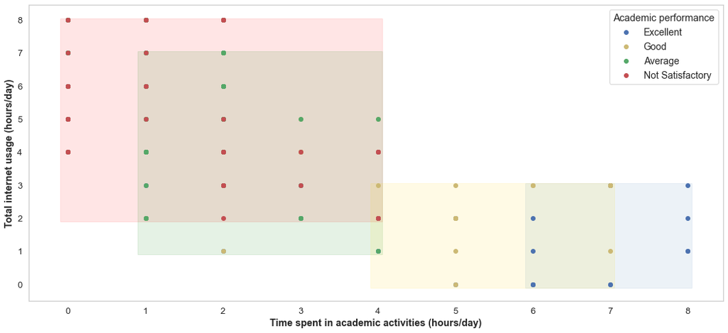

```python
categorical_scatter_plot_wrt_academic_performance(college_df,  'Time Spent in Academic(hrs/day)',
                                                  'Total Internet Usage(hrs/day)',
                                                  'Time Spent in Academic(hrs/day) vs Total Internet Usage(hrs/day)',
                                                  'Total internet usage (hours/day)',
                                                  'Time spent in academic activities (hours/day)',
                                                  'Academic performance')


plt.fill_between([-0.1, 4.05], [8.05, 8.05], 1.9, color='red', alpha=0.1, interpolate=True)
plt.fill_between([0.9, 4.05], [7.05, 7.05], 0.9, color='green', alpha=0.1, interpolate=True)
plt.fill_between([5.9, 8.05], [3.05, 3.05], -0.1, color='steelblue', alpha=0.1, interpolate=True)
plt.fill_between([3.9, 7.05], [3.05, 3.05], -0.1, color='gold', alpha=0.1, interpolate=True)

save_fig('Time_Spent_in_Academic_vs_Total_Internet_Usage_Scatter_Plot')
plt.show()
```

### Plotting `Duration Of Internet Usage(In Years)`

```python
college_df.rename(columns={
    'Years of Internet Use':'Duration Of Internet Usage(In Years)',
}, inplace=True)

college_df.columns
```

```
Index(['Gender', 'Age', 'Frequently Visited Website',
       'Effectiveness Of Internet Usage', 'Devices Used For Internet Browsing',
       'Location Of Internet Use', 'Household Internet Facilities',
       'Time Of Internet Browsing', 'Frequency Of Internet Usage',
       'Place Of Student's Residence', 'Total Internet Usage(hrs/day)',
       'Time Spent in Academic(hrs/day)', 'Purpose Of Internet Use',
       'Duration Of Internet Usage(In Years)', 'Browsing Purpose',
       'Priority Of Learning On The Internet', 'Webinar',
       'Internet Usage For Educational Purpose', 'Academic Performance',
       'Barriers To Internet Access'],
      dtype='object')
```

```python
college_df['Duration Of Internet Usage(In Years)'].value_counts()
```

```
3    60
1    44
2    43
4    32
5    18
7     2
Name: Duration Of Internet Usage(In Years), dtype: int64
```

```
Saving figure Non_Categorical_Bar_plot_2
```

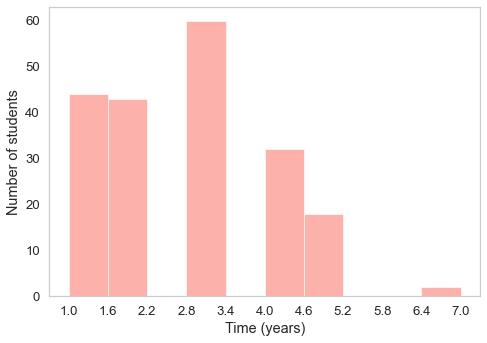

```python
plt.figure(figsize=(7, 5))
plt.subplots_adjust(top=0.5, bottom=0.1, hspace=0.5, wspace=0.2)
sns.set(font_scale=1.2)
sns.set_style("whitegrid", {'axes.grid' : False})

numerical_data_plot(college_df['Duration Of Internet Usage(In Years)'], 'Duration_Of_Internet_Usage_Histogram',
                    hist_alpha=0.6, color='salmon',
                    title='How long have the students been using internet?', xlabel='Time (years)',
                    ylabel='Number of students')


save_fig('Non_Categorical_Bar_plot_2')

plt.show()
```

Now let's check the scatter plot.

```
Saving figure Duration_Of_Internet_Usage_In_Years_Scatter_Plot
```

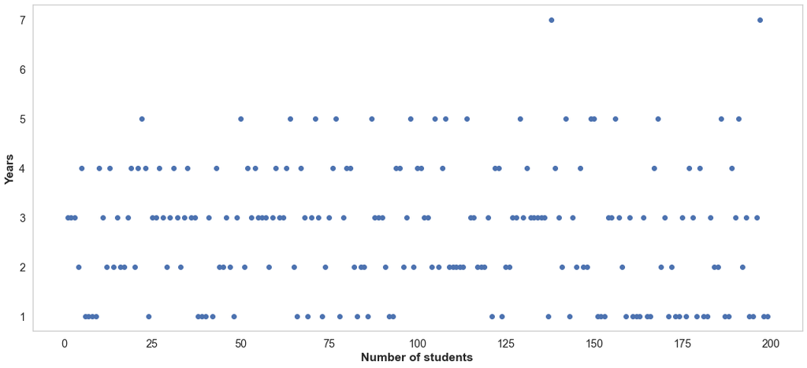

```python
plt.figure(figsize=(15, 7))
sns.set(font_scale=1.3)
sns.set_style("whitegrid", {'axes.grid' : False})

plt.plot(np.linspace(1, len(college_df.index), len(college_df.index)),
         college_df['Duration Of Internet Usage(In Years)'], 'bo')

# plt.title('Duration Of Internet Usage (In Years)', fontweight='bold')
plt.ylabel('Years', fontweight='bold')
plt.xlabel('Number of students', fontweight='bold')

save_fig('Duration_Of_Internet_Usage_In_Years_Scatter_Plot')
plt.show()
```

Now let's try plotting `'Years of Internet Use'` against the target column `'Academic Performance'`.

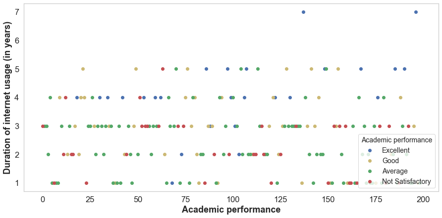

```python
categorical_scatter_plot(college_df, 'Duration Of Internet Usage(In Years)', 'Academic Performance',
                         'Duration Of Internet Usage(In Years) vs Academic Performance', 'Academic performance',
                         'Duration of internet usage (in years)', 'Academic performance')
```

**Now let's try plotting `Time Spent in Academic(hrs/day)` vs `'Duration Of Internet Usage(In Years)'` against the target `'Academic Performance'`.**

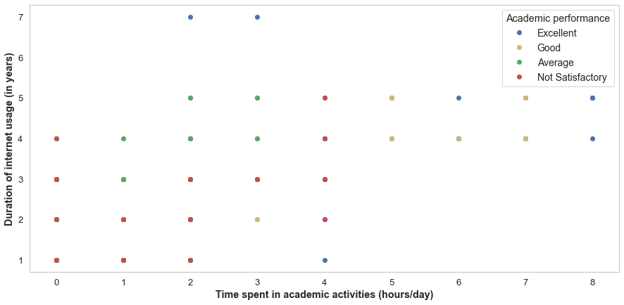

```python
categorical_scatter_plot_wrt_academic_performance(college_df, 'Time Spent in Academic(hrs/day)',
                                                  'Duration Of Internet Usage(In Years)',
                                                  'Time Spent in Academic (hrs/day) vs Duration Of Internet Usage (In Years)',
                                                  'Duration of internet usage (in years)',
                                                  'Time spent in academic activities (hours/day)', 'Academic performance')

plt.show()
```

**Now let's try plotting `'Total Internet Usage(hrs/day)'` vs `'Duration Of Internet Usage(In Years)'` against the target `'Academic Performance'`.**

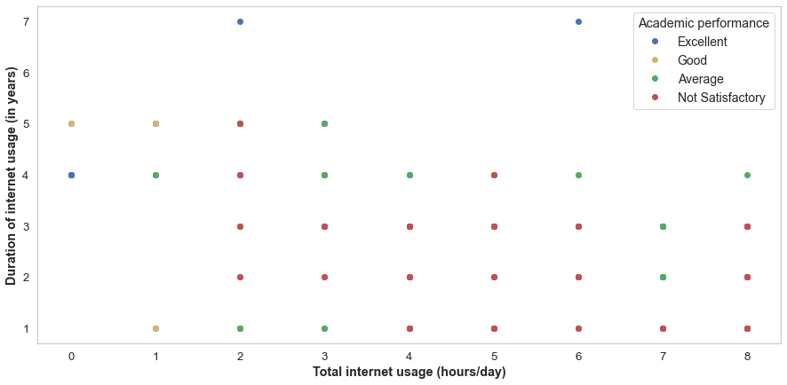

```python
categorical_scatter_plot_wrt_academic_performance(college_df, 'Total Internet Usage(hrs/day)',
                                                  'Duration Of Internet Usage(In Years)',
                                                  'Total Internet Usage (hrs/day) vs Duration Of Internet Usage (In Years)',
                                                  'Duration of internet usage (in years)',
                                                  'Total internet usage (hours/day)', 'Academic performance')

plt.show()
```

### Plotting Categorical Values

`'Gender'`, `'Age'`, `'Frequently Visited Website'`, `'Effectiveness Of Internet Usage'`, `'Devices Used For Internet Browsing'`, `'Location Of Internet Use'`, `'Household Internet Facilities'`, `'Time Of Internet Browsing'`, `'Frequency Of Internet Usage'`, `'Place Of Student's Residence'`, `'Purpose Of Internet Use'`, `'Browsing Purpose'`, `'Webinar'`, `'Priority Of Learning On The Internet'`, `'Academic Performance'`, `'Barriers To Internet Access'` are the categorical values in the dataset.

**Let's plot the bar plot for each of the categorical attributes together.**

```
Saving figure Bar_plot_collage_1
```

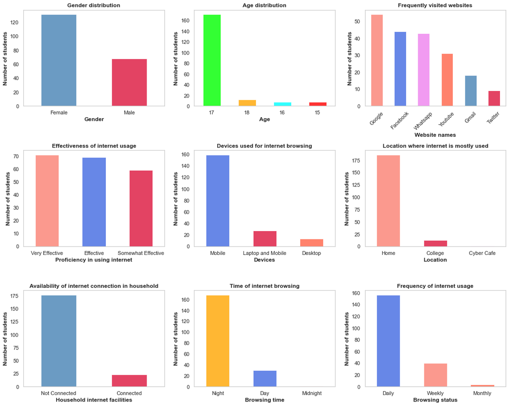

```python
plt.figure(figsize=(15, 12))
plt.subplots_adjust(top=0.5, bottom=0.1, hspace=0.5, wspace=0.2)
sns.set(font_scale=1)
sns.set_style("whitegrid", {'axes.grid' : False})

plt.subplot(331)
categorical_bar_plot(college_df['Gender'], title='Gender distribution', xlabel='Gender')

plt.subplot(332)
categorical_bar_plot(college_df['Age'],
                     color=['lime', 'orange', 'cyan', 'red', 'steelblue', 'violet'],
                     title='Age distribution', xlabel='Age')

plt.subplot(333)
categorical_bar_plot(college_df['Frequently Visited Website'], rot=45,
                     color=['salmon', 'royalblue', 'violet', 'tomato', 'steelblue', 'crimson'],
                     title='Frequently visited websites', xlabel='Website names')

plt.subplot(334)
categorical_bar_plot(college_df['Effectiveness Of Internet Usage'], color=['salmon', 'royalblue', 'crimson', 'violet'],
                     title='Effectiveness of internet usage', xlabel='Proficiency in using internet')

plt.subplot(335)
categorical_bar_plot(college_df['Devices Used For Internet Browsing'],
                     color=['royalblue', 'crimson', 'tomato', 'orange'],
                     title='Devices used for internet browsing', xlabel='Devices')

plt.subplot(336)
categorical_bar_plot(college_df['Location Of Internet Use'],
                     color=['salmon', 'crimson', 'violet', 'orange', 'steelblue'],
                     title='Location where internet is mostly used', xlabel='Location')

plt.subplot(337)
categorical_bar_plot(college_df['Household Internet Facilities'],
                     title='Availability of internet connection in household',
                     xlabel='Household internet facilities')

plt.subplot(338)
categorical_bar_plot(college_df['Time Of Internet Browsing'], color=['orange', 'royalblue', 'salmon', 'tomato'],
                     title='Time of internet browsing', xlabel='Browsing time')

plt.subplot(339)
categorical_bar_plot(college_df['Frequency Of Internet Usage'], color=['royalblue', 'salmon', 'tomato'],
                     title='Frequency of internet usage', xlabel='Browsing status')


save_fig('Bar_plot_collage_1')

plt.show()
```

```
Saving figure Bar_plot_collage_2
```

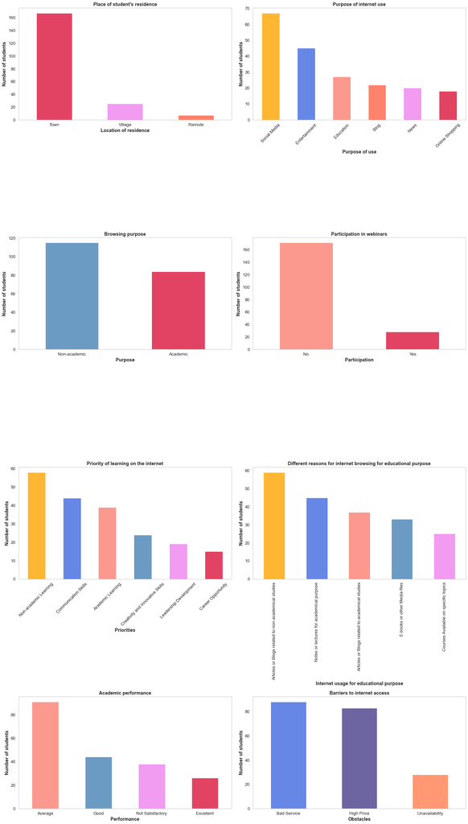

```python
plt.figure(figsize=(20, 35))
plt.subplots_adjust(top=0.5, bottom=0.1, hspace=0.5, wspace=0.2)
sns.set(font_scale=1.2)
sns.set_style("whitegrid", {'axes.grid' : False})


plt.subplot(421)
categorical_bar_plot(college_df['Place Of Student\'s Residence'], color=['crimson', 'violet', 'tomato'],
                     title='Place of student\'s residence', xlabel='Location of residence')

plt.subplot(422)
categorical_bar_plot(college_df['Purpose Of Internet Use'], rot=45,
                     color = ['orange', 'royalblue', 'salmon', 'tomato', 'violet', 'crimson'],
                     title='Purpose of internet use', xlabel='Purpose of use')

plt.subplot(423)
categorical_bar_plot(college_df['Browsing Purpose'], title='Browsing purpose',
                     xlabel='Purpose')

plt.subplot(424)
categorical_bar_plot(college_df['Webinar'], color=['salmon', 'crimson'],
                     title='Participation in webinars', xlabel='Participation')

plt.subplot(425)
categorical_bar_plot(college_df['Priority Of Learning On The Internet'], rot=45,
                     color = ['orange', 'royalblue', 'salmon', 'steelblue', 'violet', 'crimson'],
                     title='Priority of learning on the internet', xlabel='Priorities')

plt.subplot(426)
categorical_bar_plot(college_df['Internet Usage For Educational Purpose'], rot=90,
                     color=['orange', 'royalblue', 'salmon', 'steelblue', 'violet', 'crimson'],
                     title='Different reasons for internet browsing for educational purpose',
                     xlabel='Internet usage for educational purpose')

plt.subplot(427)
categorical_bar_plot(college_df['Academic Performance'], color=['salmon', 'steelblue', 'violet', 'crimson'],
                     title='Academic performance', xlabel='Performance')

plt.subplot(428)
categorical_bar_plot(college_df['Barriers To Internet Access'],
                     color=['royalblue', 'darkslateblue', 'coral', 'crimson'],
                     title='Barriers to internet access', xlabel='Obstacles')


save_fig('Bar_plot_collage_2')
plt.show()
```

### Plotting `'Gender'`

Let's check the histogram.

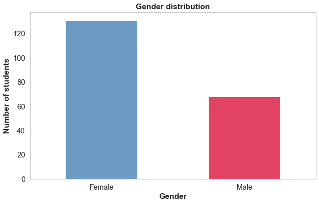

```python
plt.figure(figsize=(10, 6))
sns.set(font_scale=1.3)
sns.set_style("whitegrid", {'axes.grid' : False})

categorical_bar_plot(college_df['Gender'], title='Gender distribution', xlabel='Gender')

plt.show()
```

### Plotting `'Age'`

Let's check the histogram.

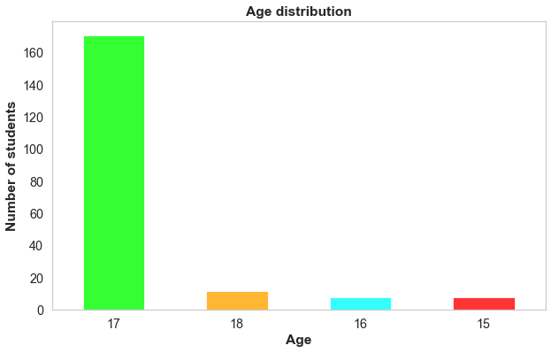

```python
plt.figure(figsize=(10, 6))
sns.set(font_scale=1.3)
sns.set_style("whitegrid", {'axes.grid' : False})

categorical_bar_plot(college_df['Age'],
                     color=['lime', 'orange', 'cyan', 'red', 'steelblue', 'violet'],
                     title='Age distribution', xlabel='Age')

plt.show()
```

### Plotting `Frequently Visited Website'`

Let's check the histogram.

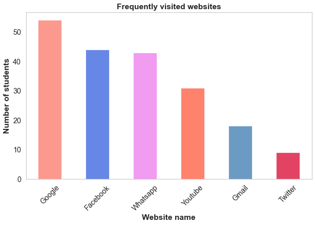

```python
plt.figure(figsize=(10, 6))
sns.set(font_scale=1.3)
sns.set_style("whitegrid", {'axes.grid' : False})

categorical_bar_plot(college_df['Frequently Visited Website'], rot=45,
                     color=['salmon', 'royalblue', 'violet', 'tomato', 'steelblue', 'crimson', 'cyan'],
                     title='Frequently visited websites', xlabel='Website name')

plt.show()
```

Let's check the distribution of this feature against the target i.e. `'Academic Performance'`.

```
Saving figure Frequently_Visited_Websites_WRT_Academic_Performance_Histogram
```

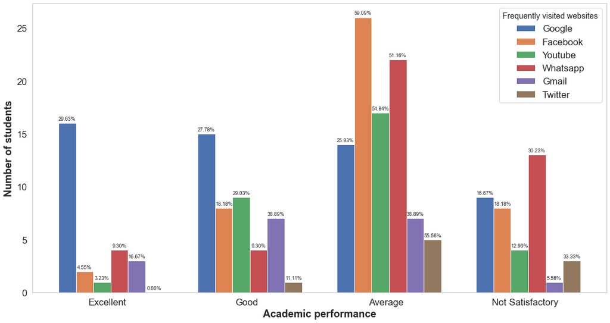

```python
sns.set(font_scale=1.5)
sns.set_style("whitegrid", {'axes.grid' : False})

dictionary = cat_vs_cat_bar_plot(college_df, 'Frequently Visited Website',
                              college_df['Frequently Visited Website'].value_counts().index.tolist())

labels = ['Excellent', 'Good', 'Average', 'Not Satisfactory']
x = np.arange(len(labels))
width = 0.25

fig, ax = plt.subplots(figsize=(15, 8))
fig.subplots_adjust(top=0.5, bottom=0.1, hspace=0.5, wspace=0.2)

rects1 = ax.bar(x - (width + 0.125), dictionary['Google'], width/2, label = 'Google')
rects2 = ax.bar(x - width, dictionary['Facebook'], width/2, label = 'Facebook')
rects3 = ax.bar(x - width/2, dictionary['Youtube'], width/2, label = 'Youtube')
rects4 = ax.bar(x, dictionary['Whatsapp'], width/2, label = 'Whatsapp')
rects5 = ax.bar(x + width/2, dictionary['Gmail'], width/2, label = 'Gmail')
rects6 = ax.bar(x + width, dictionary['Twitter'], width/2, label = 'Twitter')

ax.set_ylabel('Number of students', fontweight = 'bold')
ax.set_xlabel('Academic performance', fontweight = 'bold')
# ax.set_title('Frequently Visited Websites W.R.T. Academic Performance', fontweight = 'bold')
ax.set_xticks(x - width/3)
ax.set_xticklabels(labels)
ax.legend(title='Frequently visited websites', title_fontsize=14)

sns.set(font_scale=0.75)

autolabel(rects1)
autolabel(rects2)
autolabel(rects3)
autolabel(rects4)
autolabel(rects5)
autolabel(rects6)

fig.tight_layout()

save_fig('Frequently_Visited_Websites_WRT_Academic_Performance_Histogram')
plt.show()
```

**Let's check the distribution of this feature against the target i.e. `'Browsing Purpose'`.**

```
Saving figure Frequently_Visited_Websites_WRT_Browsing_Purpose_Histogram
```

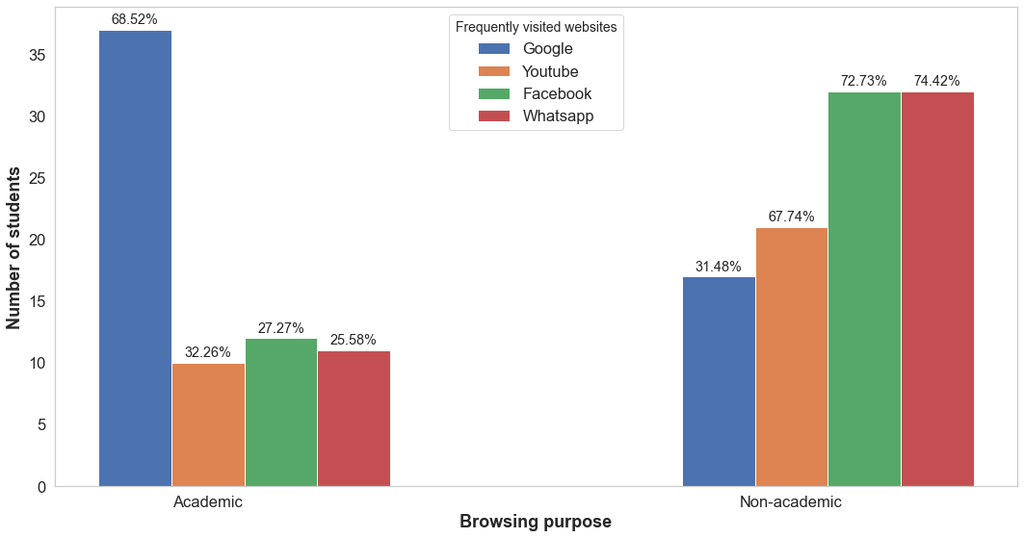

```python
sns.set(font_scale=1.5)
sns.set_style("whitegrid", {'axes.grid' : False})

dictionary = cat_vs_cat_bar_plot_browsing_purpose(college_df, 'Frequently Visited Website',
                              college_df['Frequently Visited Website'].value_counts().index.tolist())

labels = ['Academic', 'Non-academic']
x = np.arange(len(labels))
width = 0.25

fig, ax = plt.subplots(figsize=(15, 8))
fig.subplots_adjust(top=0.5, bottom=0.1, hspace=0.5, wspace=0.2)

rects1 = ax.bar(x - width, dictionary['Google'], width/2, label = 'Google')
rects2 = ax.bar(x - width/2, dictionary['Youtube'], width/2, label = 'Youtube')
rects3 = ax.bar(x, dictionary['Facebook'], width/2, label = 'Facebook')
rects4 = ax.bar(x + width/2, dictionary['Whatsapp'], width/2, label = 'Whatsapp')

ax.set_ylabel('Number of students', fontweight = 'bold')
ax.set_xlabel('Browsing purpose', fontweight = 'bold')
# ax.set_title('Frequently Visited Websites W.R.T. Browsing Purpose', fontweight = 'bold')
ax.set_xticks(x - width/2)
ax.set_xticklabels(labels)
ax.legend(title='Frequently visited websites', title_fontsize=14 ,loc='upper center')

sns.set(font_scale=1.2)

autolabel(rects1)
autolabel(rects2)
autolabel(rects3)
autolabel(rects4)

fig.tight_layout()

save_fig('Frequently_Visited_Websites_WRT_Browsing_Purpose_Histogram')
plt.show()
```

### Plotting `'Effectiveness Of Internet Usage'`

Let's check the histogram.

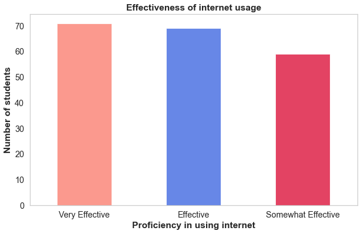

```python
plt.figure(figsize=(10, 6))
sns.set(font_scale=1.3)
sns.set_style("whitegrid", {'axes.grid' : False})

categorical_bar_plot(college_df['Effectiveness Of Internet Usage'],
                     color=['salmon', 'royalblue', 'crimson', 'violet'],
                     title='Effectiveness of internet usage', xlabel='Proficiency in using internet')

plt.show()
```

Let's check the distribution of this feature against the target i.e. `'Academic Performance'`.

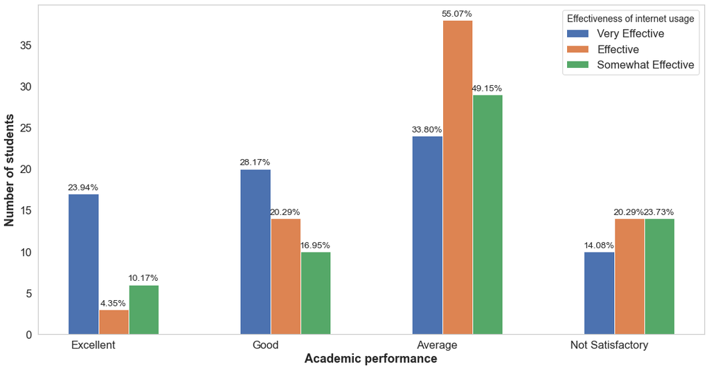

```python
sns.set(font_scale=1.5)
sns.set_style("whitegrid", {'axes.grid' : False})

dictionary = cat_vs_cat_bar_plot(college_df, 'Effectiveness Of Internet Usage',
                              ['Very Effective', 'Effective', 'Somewhat Effective'])

labels = ['Excellent', 'Good', 'Average', 'Not Satisfactory']
x = np.arange(len(labels))
width = 0.35

fig, ax = plt.subplots(figsize=(15, 8))
fig.subplots_adjust(top=0.5, bottom=0.1, hspace=0.5, wspace=0.2)

rects1 = ax.bar(x - width/2, dictionary['Very Effective'], width/2, label = 'Very Effective')
rects2 = ax.bar(x, dictionary['Effective'], width/2, label = 'Effective')
rects3 = ax.bar(x + width/2, dictionary['Somewhat Effective'], width/2, label = 'Somewhat Effective')

ax.set_ylabel('Number of students', fontweight = 'bold')
ax.set_xlabel('Academic performance', fontweight = 'bold')
# ax.set_title('Effectiveness Of Internet Usage vs Academic Performance', fontweight = 'bold')
ax.set_xticks(x - width/3)
ax.set_xticklabels(labels)
ax.legend(title='Effectiveness of internet usage', title_fontsize=14)

sns.set(font_scale=1.15)

autolabel(rects1)
autolabel(rects2)
autolabel(rects3)

fig.tight_layout()

plt.show()
```

### Plotting `'Devices Used For Internet Browsing'`

Let's check the histogram.

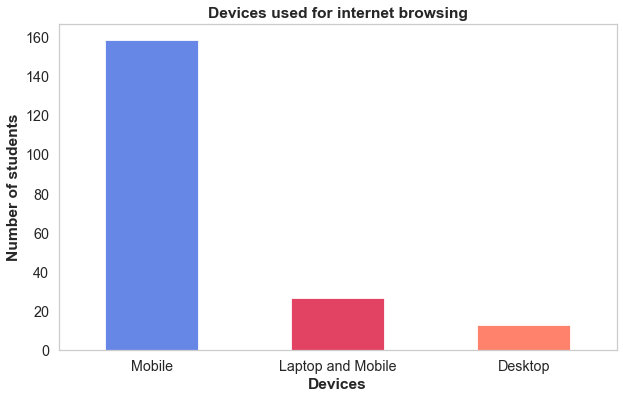

```python
plt.figure(figsize=(10, 6))
sns.set(font_scale=1.3)
sns.set_style("whitegrid", {'axes.grid' : False})

categorical_bar_plot(college_df['Devices Used For Internet Browsing'],
                     color=['royalblue', 'crimson', 'tomato', 'orange'],
                     title='Devices used for internet browsing', xlabel='Devices')

plt.show()
```

### Plotting `'Location Of Internet Use'`

Let's check the histogram.

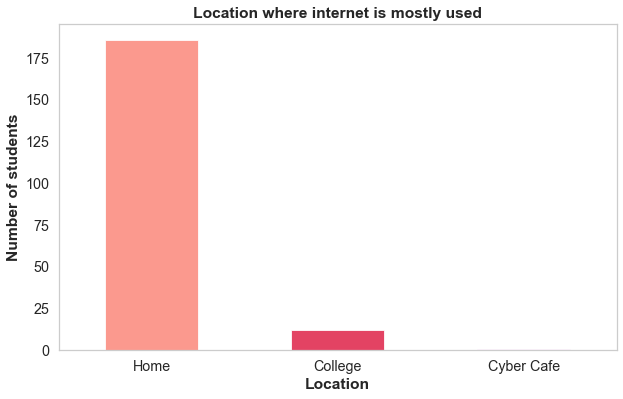

```python
plt.figure(figsize=(10, 6))
sns.set(font_scale=1.3)
sns.set_style("whitegrid", {'axes.grid' : False})

categorical_bar_plot(college_df['Location Of Internet Use'],
                     color=['salmon', 'crimson', 'violet', 'orange', 'steelblue'],
                     title='Location where internet is mostly used', xlabel='Location')

plt.show()
```

### Plotting `'Household Internet Facilities'`

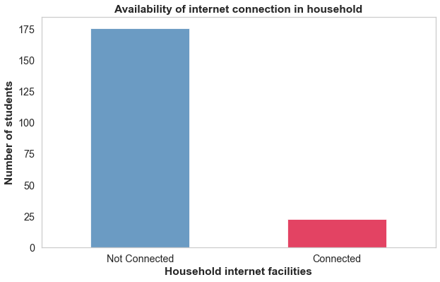

```python
plt.figure(figsize=(10, 6))
sns.set(font_scale=1.3)
sns.set_style("whitegrid", {'axes.grid' : False})

categorical_bar_plot(college_df['Household Internet Facilities'],
                     title='Availability of internet connection in household',
                     xlabel='Household internet facilities')

plt.show()
```

Let's check the distribution of this feature against the target i.e. `'Academic Performance'`.

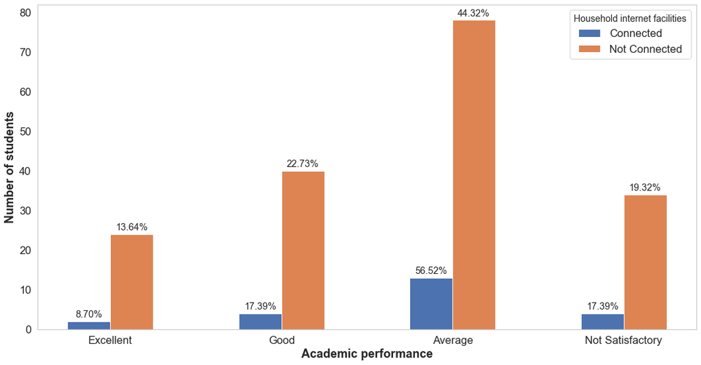

```python
sns.set(font_scale=1.5)
sns.set_style("whitegrid", {'axes.grid' : False})

dictionary = cat_vs_cat_bar_plot(college_df, 'Household Internet Facilities',
                              college_df['Household Internet Facilities'].value_counts().index.tolist())

labels = ['Excellent', 'Good', 'Average', 'Not Satisfactory']
x = np.arange(len(labels))
width = 0.25

fig, ax = plt.subplots(figsize=(15, 8))
fig.subplots_adjust(top=0.5, bottom=0.1, hspace=0.5, wspace=0.2)

rects1 = ax.bar(x - width, dictionary['Connected'], width, label = 'Connected')
rects2 = ax.bar(x, dictionary['Not Connected'], width, label = 'Not Connected')

ax.set_ylabel('Number of students', fontweight = 'bold')
ax.set_xlabel('Academic performance', fontweight = 'bold')
# ax.set_title('Availability Of Internet Connection In Household vs Academic Performance', fontweight = 'bold')
ax.set_xticks(x - width/2)
ax.set_xticklabels(labels)
ax.legend(title='Household internet facilities', title_fontsize=14)

sns.set(font_scale=1.2)

autolabel(rects1)
autolabel(rects2)

fig.tight_layout()

plt.show()
```

### Plotting `'Time Of Internet Browsing'`

Let's check the histogram.

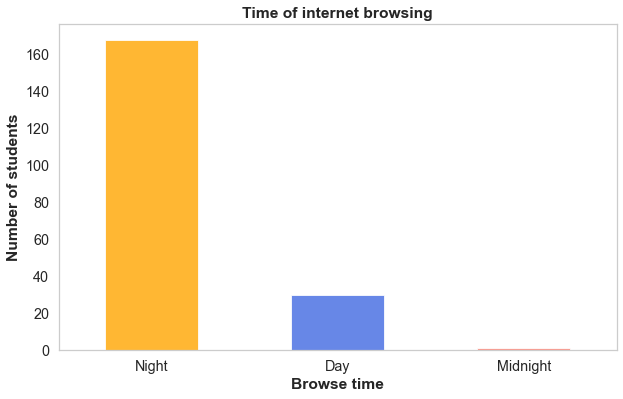

```python
plt.figure(figsize=(10, 6))
sns.set(font_scale=1.3)
sns.set_style("whitegrid", {'axes.grid' : False})

categorical_bar_plot(college_df['Time Of Internet Browsing'], color=['orange', 'royalblue', 'salmon', 'tomato'],
                     title='Time of internet browsing', xlabel='Browse time')

plt.show()
```

Let's check the distribution of this feature against the target i.e. `'Academic Performance'`.

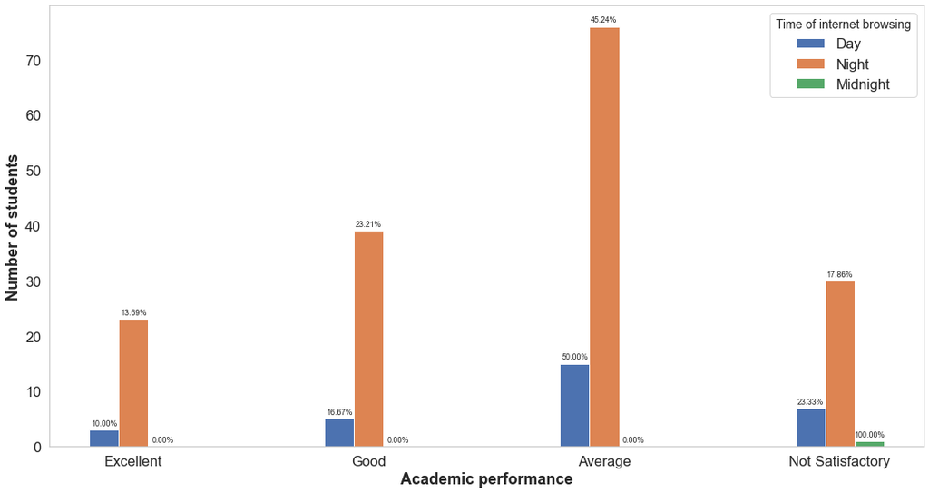

```python
sns.set(font_scale=1.5)
sns.set_style("whitegrid", {'axes.grid' : False})

dictionary = cat_vs_cat_bar_plot(college_df, 'Time Of Internet Browsing',
                              ['Day', 'Night', 'Midnight'])

labels = ['Excellent', 'Good', 'Average', 'Not Satisfactory']
x = np.arange(len(labels))
width = 0.25

fig, ax = plt.subplots(figsize=(15, 8))
fig.subplots_adjust(top=0.5, bottom=0.1, hspace=0.5, wspace=0.2)

rects1 = ax.bar(x - width/2, dictionary['Day'], width/2, label = 'Day')
rects2 = ax.bar(x, dictionary['Night'], width/2, label = 'Night')
rects3 = ax.bar(x + width/2, dictionary['Midnight'], width/2, label = 'Midnight')

ax.set_ylabel('Number of students', fontweight = 'bold')
ax.set_xlabel('Academic performance', fontweight = 'bold')
# ax.set_title('Time Of Internet Browsing vs Academic Performance', fontweight = 'bold')
ax.set_xticks(x)
ax.set_xticklabels(labels)
ax.legend(title='Time of internet browsing', title_fontsize=14)

sns.set(font_scale=0.75)

autolabel(rects1)
autolabel(rects2)
autolabel(rects3)

fig.tight_layout()

plt.show()
```

### Plotting `'Frequency Of Internet Usage'`

Let's check the histogram.

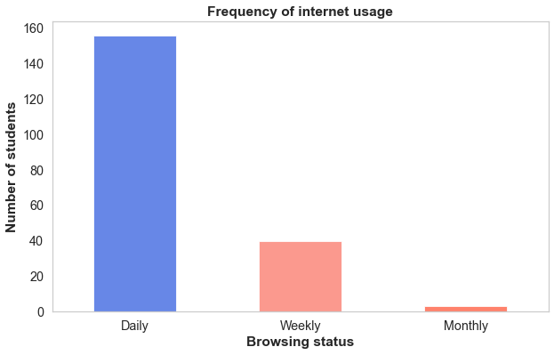

```python
plt.figure(figsize=(10, 6))
sns.set(font_scale=1.3)
sns.set_style("whitegrid", {'axes.grid' : False})

categorical_bar_plot(college_df['Frequency Of Internet Usage'], color=['royalblue', 'salmon', 'tomato'],
                     title='Frequency of internet usage', xlabel='Browsing status')

plt.show()
```

Let's check the distribution of this feature against the target i.e. `'Academic Performance'`.

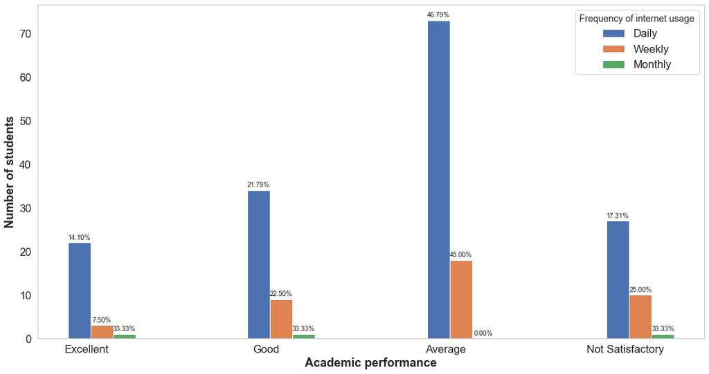

```python
sns.set(font_scale=1.5)
sns.set_style("whitegrid", {'axes.grid' : False})

dictionary = cat_vs_cat_bar_plot(college_df, 'Frequency Of Internet Usage',
                              ['Daily', 'Weekly', 'Monthly'])

labels = ['Excellent', 'Good', 'Average', 'Not Satisfactory']
x = np.arange(len(labels))
width = 0.25

fig, ax = plt.subplots(figsize=(15, 8))
fig.subplots_adjust(top=0.5, bottom=0.1, hspace=0.5, wspace=0.2)

rects1 = ax.bar(x - width/2, dictionary['Daily'], width/2, label = 'Daily')
rects2 = ax.bar(x, dictionary['Weekly'], width/2, label = 'Weekly')
rects3 = ax.bar(x + width/2, dictionary['Monthly'], width/2, label = 'Monthly')

ax.set_ylabel('Number of students', fontweight = 'bold')
ax.set_xlabel('Academic performance', fontweight = 'bold')
# ax.set_title('Frequency Of Internet Usage vs Academic Performance', fontweight = 'bold')
ax.set_xticks(x - width/3)
ax.set_xticklabels(labels)
ax.legend(title='Frequency of internet usage', title_fontsize=14)

sns.set(font_scale=0.85)

autolabel(rects1)
autolabel(rects2)
autolabel(rects3)

fig.tight_layout()

plt.show()
```

### Plotting `'Place Of Student's Residence'`

Let's check the histogram.

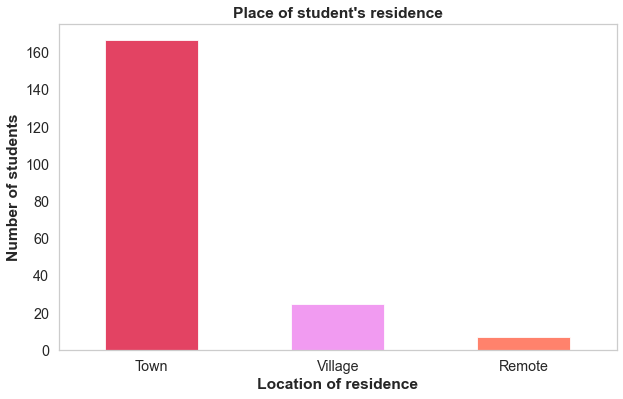

```python
plt.figure(figsize=(10, 6))
sns.set(font_scale=1.3)
sns.set_style("whitegrid", {'axes.grid' : False})

categorical_bar_plot(college_df['Place Of Student\'s Residence'], color=['crimson', 'violet', 'tomato'],
                     title='Place of student\'s residence', xlabel='Location of residence')

plt.show()
```